# Sécurisation des communications

## Définitions

**Cryptographie**

La cryptographie est un ensemble de procédés et de techniques qui permet de rendre un message incompréhensible pour en conserver le secret. Les techniques utilisées s'appuient sur des algorithmes et des clefs de chiffrement.

**Cryptanalyse**

La cryptanalyse est un ensemble de procédés et de techniques qui permet de déchiffrer un message sans avoir connaissance des clefs de chiffrement.

**Chiffrer**

Rendre un message incompréhensible en utilisant des clefs de chiffrement et des algorithmes de cryptage.

**Déchiffrer**

Rendre un message compréhensible, dans la forme avant chiffrement en utilisant des clefs de déchiffrement et des algorithmes.

## La cryptographie symétrique

La méhode de chiffrement symétrique utilise une clef qui est la même pour le **chiffrement** et le **déchiffrement**.

Le procédé de chiffrement est plus complexe qu'un simple décalage de valeurs dans un alphabet.

### Principe

La cryptographie symétrique utilise deux fonctions :

- une fonction $C(m,k)$ pour chiffrer qui prend en argument un message **m** et une clef de chiffrement **k** et renvoie un message chiffré **m'**.
- une fonction de déchiffrement $D(m',k)$ qui prend en argument un message chiffré **m'** et la clef de chiffrement $k$ et renvoie le message déchiffré **m**.

### Exemple

Le chiffrement de César est symétrique :

- la clef **k** est identique pour chiffrer et déchiffrer le message;
- on a une fonction $C$ pour chiffrer et une fonction $D$ pour déchiffrer le message.

Le chiffrement de Vigenère est symétrique aussi:

- la clef **k** est identique pour chiffrer et déchiffrer le message; elle dépend de la longueur du mot clef.
- on a une fonction $C$ pour chiffrer et une fonction $D$ pour déchiffrer le message.

### Chiffrement par XOR

Le **ou exclusif** ou **XOR** est un opérateur logique noté $\oplus$. La table de vérité est:

| X | Y | X $\oplus$Y |
| --- | --- | --- |
| 0 | 0 | 0 |
| 0 | 1 | 1 |
| 1 | 0 | 1 |
| 1 | 1 | 0 |

Une propriété intéressante de l'opérateur **XOR** est qu'il est réversible: si $A \oplus B = C$ alors $A \oplus C = B$ et $B \oplus C = A$

Cette propriété permet alors de déchiffrer un message :

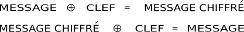

### Exemple

La lettre S a pour code décimal $83$ dans la table ASCII ou UNICODE soit $0101 0011$ en binaire;

La lettre P a pour code décimal $80$ dans la table ASCII ou UNICODE soit $0101 0000$ en binaire;

La valeur $83 \oplus 80$ = $0101 0011 \oplus 0101 0000$ ce qui donne, bit à bit $0000 0011$ soit 3 en décimal:

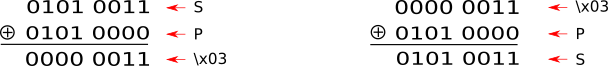

Le caractère obtenu est non imprimable et a pour valeur décimale $3$.

### Opérateur XOR en Python

En Python cet opérateur est noté par le circonflexe et s'applique à des nombres entiers. Par conséquent, pour appliquer cet opérateur logique entre deux valeurs, une conversion de la valeur en décimal est nécessaire.

- Lorsque les valeurs sont nombres entiers, l'opérateur s'applique directement : 3 ^ 4.
- Lorsque les valeurs sont des caractères quelconques, une conversion du caratère en valeur décimale est nécessaire. Ensuite, le résultat décimal pourra être transformé en caractère. Cela est alors équivalent à l'opération logique XOR avec les écritures binaires.

### Faiblesse

La cryptographie symétrique est très robuste et même impossible à déchiffrer en théorie si la clef de chiffrement est aussi longue que le message à chiffrer et utilisée une seule fois. En pratique cela n'est pas possible mais on peut tendre vers ces pratiques ce qui rend très sûr le chiffrement.

**Quelle est la faiblesse ?**

Elle réside dans la transmission de la clef de chiffrement qui est utilisée pour chiffrer et déchiffrer le message. Cela implique, à un instant donné, de transmettre la clef et donc un risque d'interception.

Pour conclure, les algorithmes de chiffrement symétriques comme AES (Advanced Encryption Standard) reposent sur un chiffrement similaire au chiffrement XOR avec une clef initiale étendue mais pas en la répétant naïvement comme pour Vigenère.

Ce chiffrement est très sûr et surtout très rapide car l'opérateur **XOR** est directement intégré à l'unité arithmétique des processeurs, ce qui permet de chiffrer des flux instantannément comme l'audio ou la vidéo.